# Analyze Modality Correlations

Jeremy Jacobson

January 29, 2026

### Purpose

This notebook is designed to take the drug viability data and the long-format omics tables (RNA, global, and phospho), then compute and plot correlations between drug response and molecular features. These long-format omics tables are batch corrected when necessary and have been returned from the Normalize Omics Notebook.

The `analyze_modality` will load the inputs from Synapse, build the matrices, save the plots, and return the correlation results so we can quickly inspect them. This markdown file also uses a `pdf_to_png_if_possible` function to help display the plots directly in the knitted markdown file.

### Get Helper Scripts

These scripts contain the functions that we will call below.

- 00_cNF_helper_code.R is a basic helper script (Synapse helpers, metadata, and shared utilities).
- 02_analyze_modality_correlations.R contains the code for building matrices, plotting summaries, and computing correlations.

## Load in Data

These are the four main inputs we need. Drug viability plus the three long-format omics tables.

```r
# Drugs
drugs <- readr::read_tsv(synGet("syn69947322")$path)

# RNA
rlong <- readr::read_csv(synGet("syn71333780")$path)

# Global
glong <- readr::read_csv(synGet("syn70078416")$path)

# Phospho
plong <- readr::read_csv(synGet("syn70078415")$path)
```

## Run correlations per modality

Below, we run the same workflow three times, once per modality. The only thing that changes is which omics table we use and which column identifies the feature.

The RNA step calls `analyze_modality()` (end-to-end) which:  
- Builds a sample x drug matrix and a sample x feature matrix.  
- Saves drug summary plots to the output directory (most_efficacious, most_variable, and the heatmap).  
- Computes Spearman correlations between drug response and molecular features.  
- Returns the results as a list so we can inspect them directly in R.

For global and phospho, we call `analyze_modality_correlations()` only, which:  
- Reuses the drug matrix from the RNA run.  
- Builds the sample x feature matrix for that modality.  
- Computes Spearman correlations between drug response and molecular features.  
- Saves the correlation feature summary plot.

A few plot notes (these get written to `outdir`):  
- **most_efficacious.pdf**: drugs with the lowest mean viability across samples. This is basically a “top hits” plot.  
- **most_variable.pdf**: drugs with the highest variability across samples. These are the ones that may be more sample-dependent.  
- **drug_heatmap_large_viability.pdf**: a large sample-by-drug heatmap, but only for drugs measured in all samples. This is useful for clustering and spotting outliers. Samples/patients are separated by lines, within each are 1-3 tumors.  
- **cor_features_by_drug.pdf**: counts of significant correlated features per drug (split by direction). This is a quick way to see which drugs have real signal in this modality.

**Note**: `most_efficacious`, `most_variable`, and `drug_heatmap_large_viability` are based on the drug response table, not the omics table.  
They get recreated on every end-to-end run, but they are the same plots. Because of that, we run the end-to-end workflow once (RNA), and then for global/phospho we only run the modality-only correlation step.

**Note 2:** The end-to-end `analyze_modality` function may take a long time to run (~30-45 min).

### RNA

```r
corr_rna <- analyze_modality(
  fits        = drugs,
  df_long     = rlong,
  sample_col  = "Specimen",
  feature_col = "feature_id",
  value_col   = "correctedAbundance",
  metric      = "uM_viability",
  heatmap_filename = "rna_drug_heatmap_large_viability.pdf",
  outdir = "new_figs"
)

# Copy the shared filenames to RNA-specific names so later modalities don't overwrite what we want to show here
dir.create("new_figs", showWarnings = FALSE, recursive = TRUE)
file.copy("new_figs/most_efficacious.pdf", "new_figs/rna_most_efficacious.pdf", overwrite = TRUE)
file.copy("new_figs/most_variable.pdf",   "new_figs/rna_most_variable.pdf",   overwrite = TRUE)
file.copy("new_figs/cor_features_by_drug.pdf", "new_figs/rna_cor_features_by_drug.pdf", overwrite = TRUE)
```

For RNA, the “features” are the rows we test in the correlation step, and they come directly from the `feature_id` column in the RNA long table (`rlong`). In most cases `feature_id` is a gene ID (or a transcript ID, depending on how the RNA file was generated). The workflow builds a sample × feature matrix from RNA, then correlates every RNA feature against drug viability for each drug.

If a drug shows a large number of significant RNA correlations (after FDR filtering), that is a strong sign the RNA signal is tracking response for that drug. In other words, the transcriptome is separating the sensitive vs resistant samples for that drug in a consistent way.

Below are the plots I show right after running RNA. This is the only place I show the drug-only plots, because those are based on the drug response table and are essentially the same no matter which omics table we are using.

**Positive Correlation** indicates a **higher viability** which means that there is **lower effect** of the drug / **higher resistance** to the drug.

**Negative Correlation** indicates a **lower viability** which means that there is **greater effect** of the drug / **higher sensitivity** to the drug.

Metric used: `uM_viability`

Files shown for RNA:  
- new_figs/rna_most_efficacious.pdf  
- new_figs/rna_most_variable.pdf  
- new_figs/rna_drug_heatmap_large_viability.pdf  
- new_figs/rna_cor_features_by_drug.pdf

```
## Converting page 1 to rna_most_efficacious_1.png... done!
## Converting page 1 to rna_most_variable_1.png... done!
## Converting page 1 to rna_drug_heatmap_large_viability_1.png... done!
## Converting page 1 to rna_cor_features_by_drug_1.png... done!
```

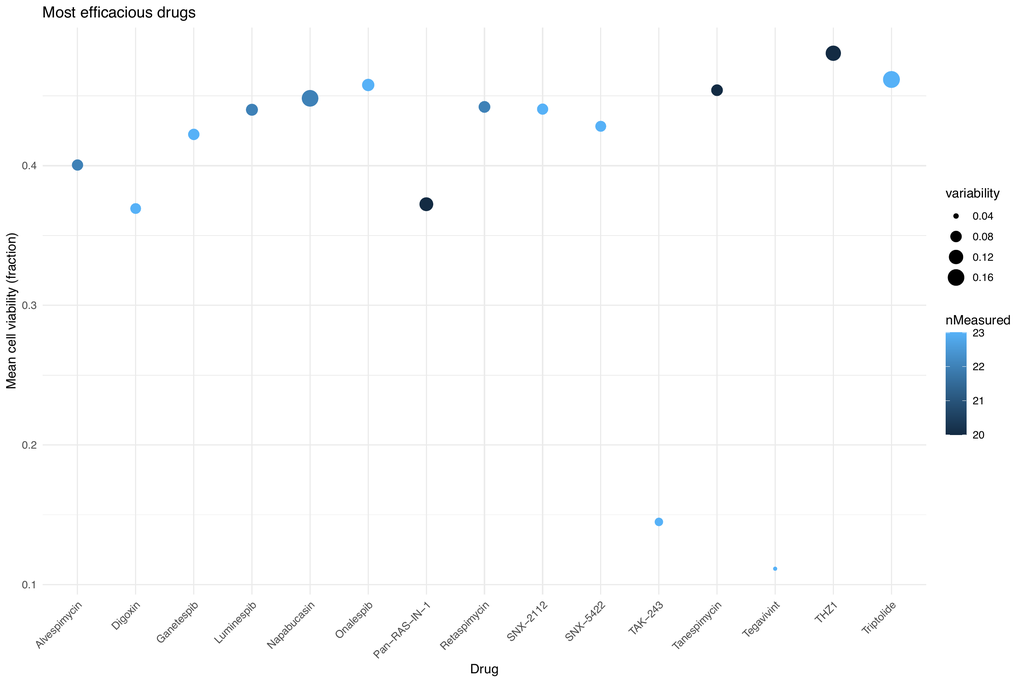

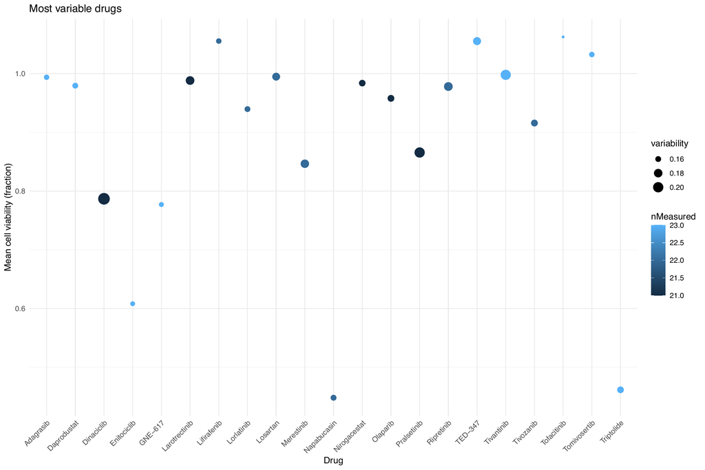

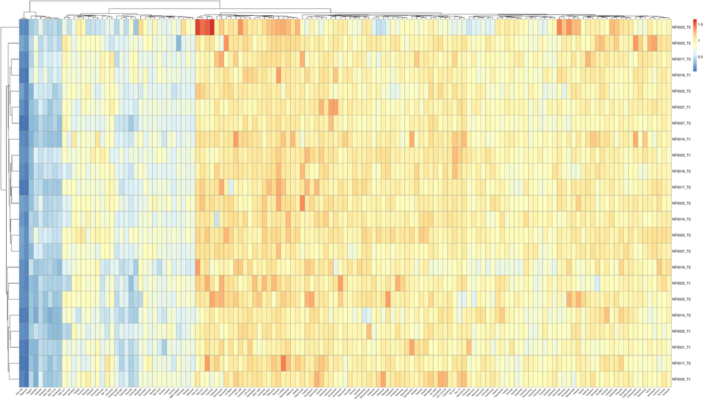

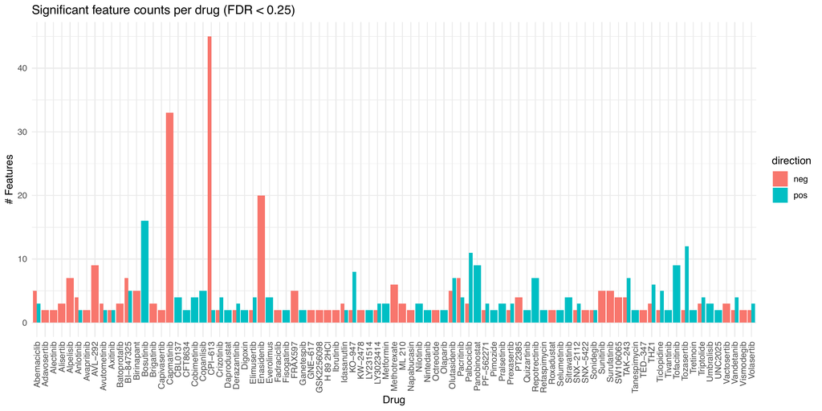

### Global Proteomics

```r
corr_global <- analyze_modality_correlations(
  df_long     = glong,
  sample_col  = "Specimen",
  feature_col = "Gene",
  value_col   = "correctedAbundance",
  drug_mat    = corr_rna$drug_mat,
  outdir      = "new_figs",
  fdr_thresh  = 0.25
)

# Copy the shared filenames to global-specific names
file.copy("new_figs/cor_features_by_drug.pdf", "new_figs/global_cor_features_by_drug.pdf", overwrite = TRUE)
```

For global proteomics, the features are proteins. In theory, these may be closer to the phenotype than RNA.

Global correlation plot

```
## Converting page 1 to global_cor_features_by_drug_1.png... done!
```

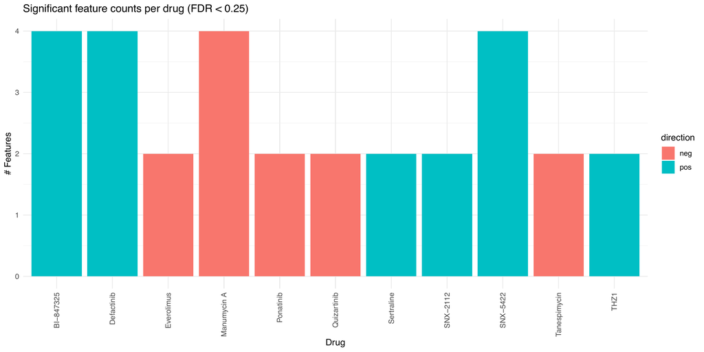

### Phospho Proteomics

```r
corr_phospho <- analyze_modality_correlations(
  df_long     = plong,
  sample_col  = "Specimen",
  feature_col = "site",
  value_col   = "correctedAbundance",
  drug_mat    = corr_rna$drug_mat,
  outdir      = "new_figs",
  fdr_thresh  = 0.25
)

# Copy the shared filenames to phospho-specific names
file.copy("new_figs/cor_features_by_drug.pdf", "new_figs/phospho_cor_features_by_drug.pdf", overwrite = TRUE)
```

For phospho, the features are phosphorylation sites. It is normal for this to be noisier and higher-dimensional, but when a drug shows a cluster of correlated sites, it can be really informative for the mechanism - however, there is just one correlation here with 2 features.

Here is the phospho correlation plot - for some reason, this one doesn’t always knit correctly, so I’m adding the table too.

```
## Converting page 1 to phospho_cor_features_by_drug_1.png... done!
```

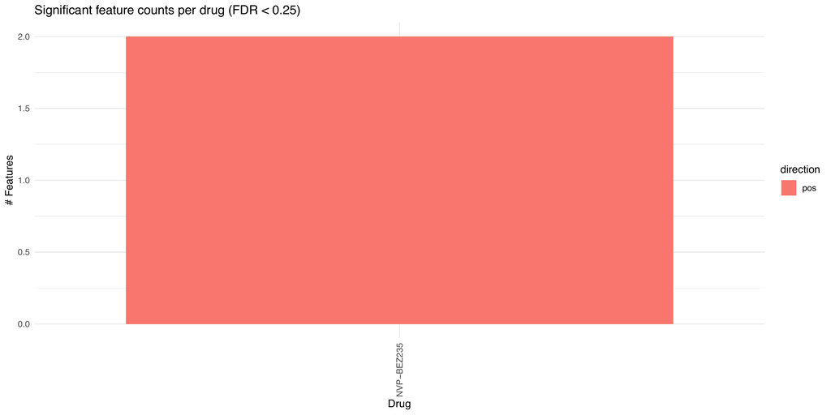

```r
corr_phospho$cor_summary
```

```
## # A tibble: 5 × 4
##   drug        direction features meanCor
##   <chr>       <chr>        <int>   <dbl>
## 1 Daporinad   pos              1   0.847
## 2 ML 210      neg              1  -0.853
## 3 NVP-BEZ235  pos              2   0.864
## 4 Tofacitinib pos              1   0.868
## 5 Tovorafenib pos              1   0.891
```